# 3. Logistic regression

## Read the previously created data, print it and described it briefly

```r
#Read the created data
alc <- read_csv("data/alc.csv")
names(alc)
```

```
##  [1] "school"     "sex"        "age"        "address"    "famsize"
##  [6] "Pstatus"    "Medu"       "Fedu"       "Mjob"       "Fjob"
## [11] "reason"     "guardian"   "traveltime" "studytime"  "schoolsup"
## [16] "famsup"     "activities" "nursery"    "higher"     "internet"
## [21] "romantic"   "famrel"     "freetime"   "goout"      "Dalc"
## [26] "Walc"       "health"     "failures"   "paid"       "absences"
## [31] "G1"         "G2"         "G3"         "alc_use"    "high_use"
```

#This data set includes information about student achievement in secondary education from two Portuguese schools. Two datasets are combined, including performance info from two different subject: math and Portuguese. Detailed information of variables in the data sets can be seen below: # Attributes for both student-mat.csv (Math course) and student-por.csv (Portuguese language course) datasets:

1 school - student’s school (binary: ‘GP’ - Gabriel Pereira or ‘MS’ - Mousinho da Silveira)

2 sex - student’s sex (binary: ‘F’ - female or ‘M’ - male)

3 age - student’s age (numeric: from 15 to 22)

4 address - student’s home address type (binary: ‘U’ - urban or ‘R’ - rural)

5 famsize - family size (binary: ‘LE3’ - less or equal to 3 or ‘GT3’ - greater than 3)

6 Pstatus - parent’s cohabitation status (binary: ‘T’ - living together or ‘A’ - apart)

7 Medu - mother’s education (numeric: 0 - none, 1 - primary education (4th grade), 2 – 5th to 9th grade, 3 – secondary education or 4 – higher education)

8 Fedu - father’s education (numeric: 0 - none, 1 - primary education (4th grade), 2 – 5th to 9th grade, 3 – secondary education or 4 – higher education)

9 Mjob - mother’s job (nominal: ‘teacher’, ‘health’ care related, civil ‘services’ (e.g. administrative or police), ‘at_home’ or ‘other’)

10 Fjob - father’s job (nominal: ‘teacher’, ‘health’ care related, civil ‘services’ (e.g. administrative or police), ‘at_home’ or ‘other’)

11 reason - reason to choose this school (nominal: close to ‘home’, school ‘reputation’, ‘course’ preference or ‘other’)

12 guardian - student’s guardian (nominal: ‘mother’, ‘father’ or ‘other’)

13 traveltime - home to school travel time (numeric: 1 - <15 min., 2 - 15 to 30 min., 3 - 30 min. to 1 hour, or 4 - >1 hour)

14 studytime - weekly study time (numeric: 1 - <2 hours, 2 - 2 to 5 hours, 3 - 5 to 10 hours, or 4 - >10 hours)

15 failures - number of past class failures (numeric: n if 1<=n<3, else 4)

16 schoolsup - extra educational support (binary: yes or no)

17 famsup - family educational support (binary: yes or no)

18 paid - extra paid classes within the course subject (Math or Portuguese) (binary: yes or no)

19 activities - extra-curricular activities (binary: yes or no)

20 nursery - attended nursery school (binary: yes or no)

21 higher - wants to take higher education (binary: yes or no)

22 internet - Internet access at home (binary: yes or no)

23 romantic - with a romantic relationship (binary: yes or no)

24 famrel - quality of family relationships (numeric: from 1 - very bad to 5 - excellent)

25 freetime - free time after school (numeric: from 1 - very low to 5 - very high)

26 goout - going out with friends (numeric: from 1 - very low to 5 - very high)

27 Dalc - workday alcohol consumption (numeric: from 1 - very low to 5 - very high)

28 Walc - weekend alcohol consumption (numeric: from 1 - very low to 5 - very high)

29 health - current health status (numeric: from 1 - very bad to 5 - very good)

30 absences - number of school absences (numeric: from 0 to 93)

#these grades are related with the course subject, Math or Portuguese:

31 G1 - first period grade (numeric: from 0 to 20)

31 G2 - second period grade (numeric: from 0 to 20)

32 G3 - final grade (numeric: from 0 to 20, output target

# To study the relationship between high/low alcohol consumption I choose the following variables. Mother’s education, activities, weekly study time and going out with friends.

My personal hypothesis regarding my chosen variables are the following:

Mother’s education, activities and weekly study time are negatively correlated with alcohol consumption i.e the higher the value of these variables are the lower alcohol consumption is.

Going out with friends is probably positively correlated with alcohol consumption.

# Let’s draw some graphs, first mother’s education

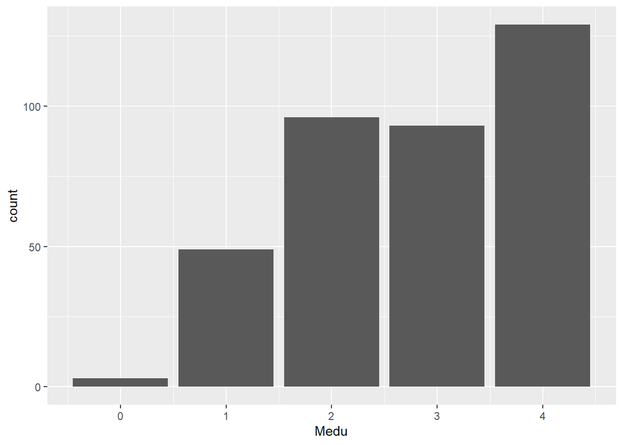

```r
#
g2 <- ggplot(data = alc, aes(x = Medu))

# define the plot as a bar plot and draw it
g2 + geom_bar()
```

```r
##cross tab

table(Medu = alc$Medu)
```

```
## Medu
##   0   1   2   3   4
##   3  49  96  93 129
```

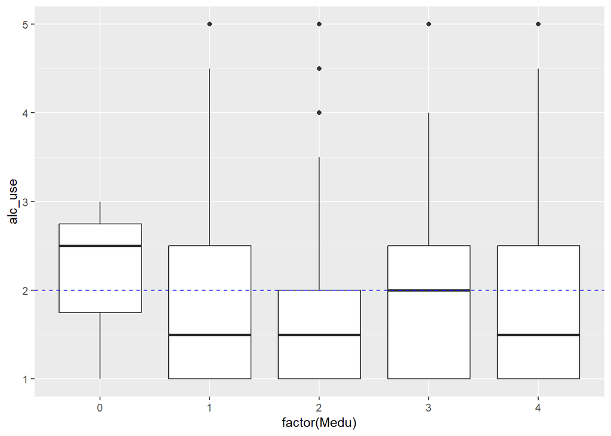

```r
#
g1 <- ggplot(data=alc, aes(x=factor(Medu),y=alc_use))

# define the plot as a boxplot and draw it
g1 +  geom_boxplot()+
  geom_hline(yintercept = 2,linetype="dashed", color="blue")
```

```r
  labs(y="Alcohol cons", x="Mother's education", title = "Alcohol consumption and mothers education")
```

```
## $y
## [1] "Alcohol cons"
##
## $x
## [1] "Mother's education"
##
## $title
## [1] "Alcohol consumption and mothers education"
##
## attr(,"class")
## [1] "labels"
```

##Based on Above graphs most of the student have mother who has at least secondary educations and less than 14% have maximum primary education. The relatioship of alcohol usage and mother’s education seems to be non-existent so there is no clear pattern. My hypothesis was wrong. The average of alcohol usage is highest in the category where mother does not have any education but there is only three obs so we should not make any conclusion based on that.

## Next variable, acitivites

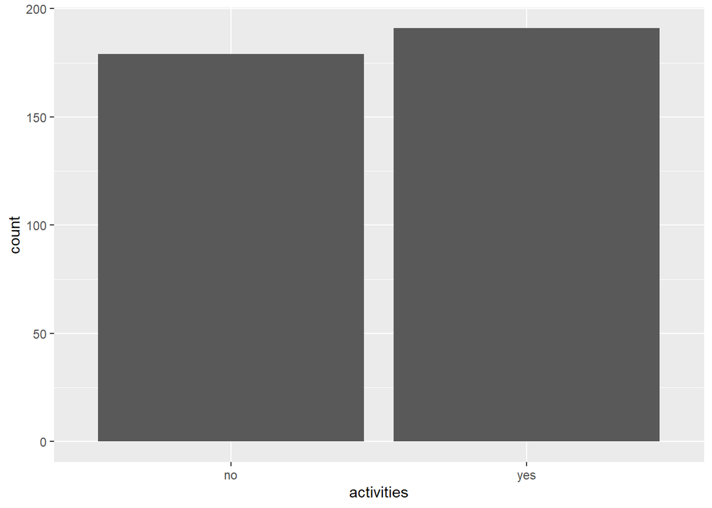

```r
#
g3 <- ggplot(data = alc, aes(x = activities))

# define the plot as a bar plot and draw it
g3 + geom_bar()
```

```r
#tabyl(alc$activities)
table(activities = alc$activities)
```

```
## activities
##  no yes
## 179 191
```

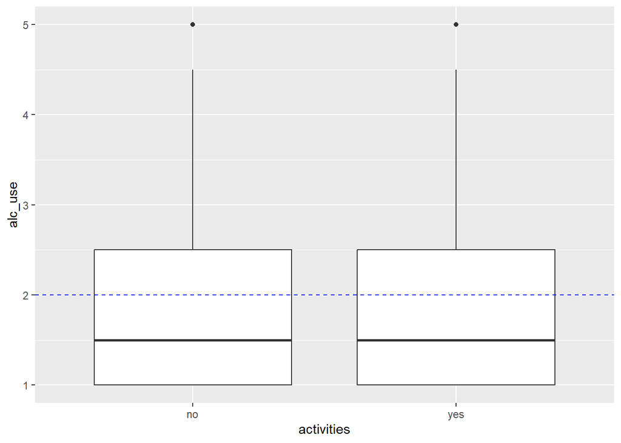

```r
#
g4 <- ggplot(data=alc, aes(x=activities,y=alc_use))

# define the plot as a boxplot and draw it
g4 +  geom_boxplot()+
  geom_hline(yintercept = 2,linetype="dashed", color="blue")
```

```r
  labs(y="Alcohol cons", x="activities", title = "Alcohol consumption and activities")
```

```
## $y
## [1] "Alcohol cons"
##
## $x
## [1] "activities"
##
## $title
## [1] "Alcohol consumption and activities"
##
## attr(,"class")
## [1] "labels"
```

##It seems that activities is almost equally distributed between yes and no. There are slightly more yes answers (51%). Surprisingly, extra activities are not related to drinking, based on the graph. My hypothesis was wrong (again), damn it.

## Next one, weekly study time

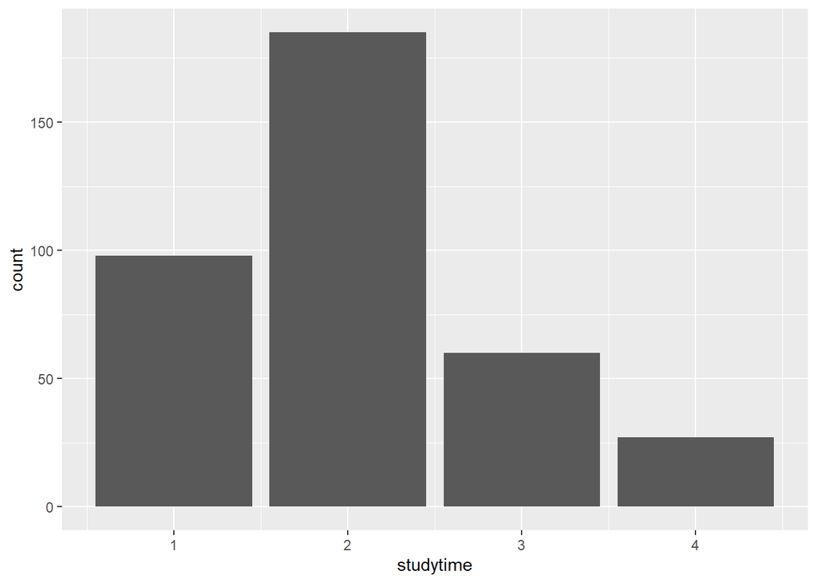

```r
#
g5 <- ggplot(data = alc, aes(x = studytime))

# define the plot as a bar plot and draw it
g5 + geom_bar()
```

```r
#tabyl(alc$studytime)
table(studytime = alc$studytime)
```

```
## studytime
##   1   2   3   4
##  98 185  60  27
```

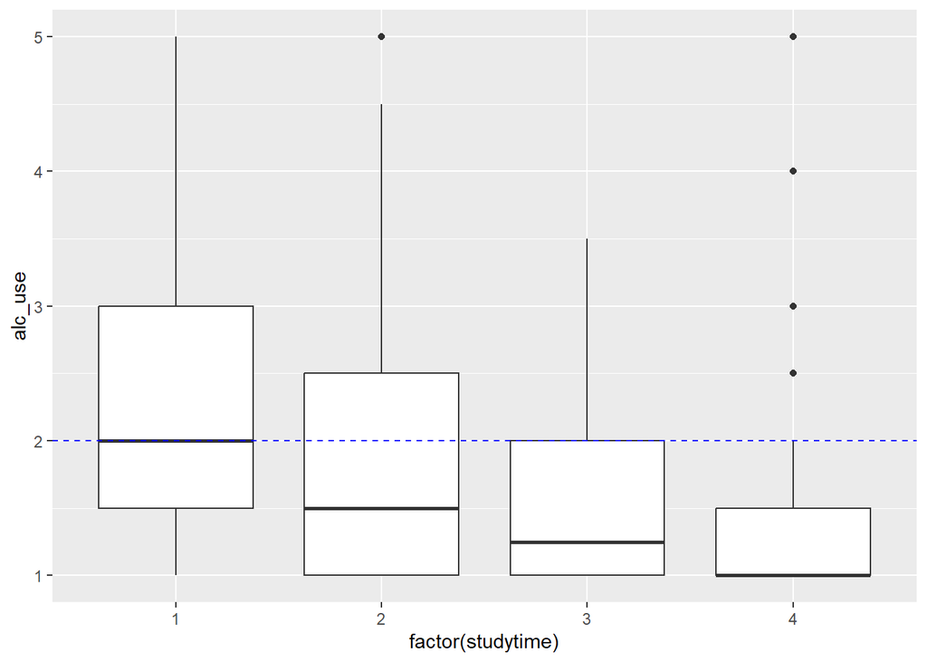

```r
#
g6 <- ggplot(data=alc, aes(x=factor(studytime),y=alc_use))

# define the plot as a boxplot and draw it
g6 +  geom_boxplot()+
  geom_hline(yintercept = 2,linetype="dashed", color="blue")
```

```r
  labs(y="Alcohol cons", x="studytime", title = "Alcohol consumption and studytime")
```

```
## $y
## [1] "Alcohol cons"
##
## $x
## [1] "studytime"
##
## $title
## [1] "Alcohol consumption and studytime"
##
## attr(,"class")
## [1] "labels"
```

Most common study time seems to be between 2-5 hours and only a small fraction studies more than ten hours in a week. Alcohol consumption decreases when study time increases, so I my hypothesis was on the right track. Vamos!

## Next one, going out with friends

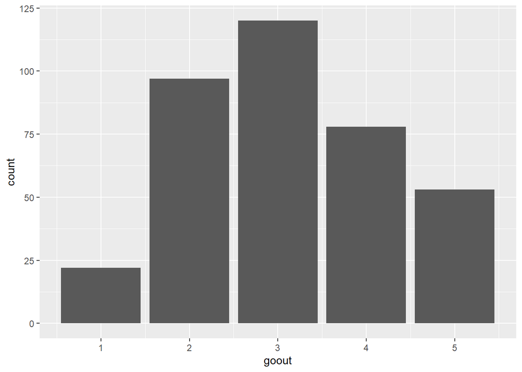

```r
#
g7 <- ggplot(data = alc, aes(x = goout))

# define the plot as a bar plot and draw it
g7 + geom_bar()
```

```r
#tabyl(alc$goout)
table(goout = alc$goout)
```

```
## goout
##   1   2   3   4   5
##  22  97 120  78  53
```

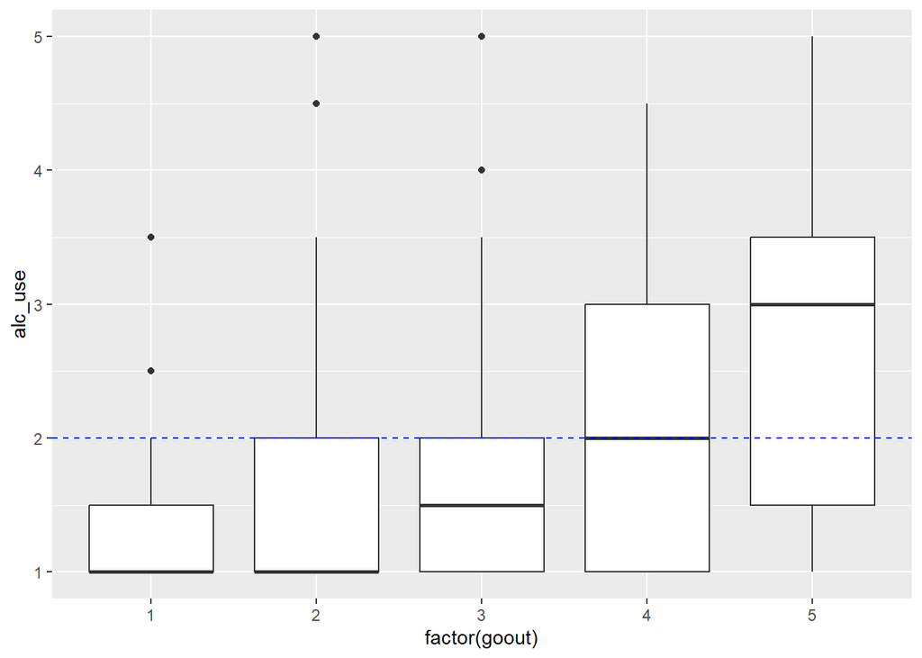

```r
#
g8 <- ggplot(data=alc, aes(x=factor(goout),y=alc_use))

# define the plot as a boxplot and draw it
g8 +  geom_boxplot()+
  geom_hline(yintercept = 2,linetype="dashed", color="blue")
```

```r
  labs(y="Alcohol cons", x="goout", title = "Alcohol consumption and studytime")
```

```
## $y
## [1] "Alcohol cons"
##
## $x
## [1] "goout"
##
## $title
## [1] "Alcohol consumption and studytime"
##
## attr(,"class")
## [1] "labels"
```

Going out variable looks almost like a normally distributed, where three is the most common and extremes are rare (1 and 5). As guessesd, alcohol consumption increases with going out.

## Logistic regression

### Estimating the model

```r
model <- glm(high_use ~ Medu + activities + studytime + goout ,family=binomial,data=alc)
summary(model)
```

```
##
## Call:
## glm(formula = high_use ~ Medu + activities + studytime + goout,
##     family = binomial, data = alc)
##
## Coefficients:
##               Estimate Std. Error z value Pr(>|z|)
## (Intercept)   -1.93014    0.58334  -3.309 0.000937 ***
## Medu          -0.02342    0.11586  -0.202 0.839797
## activitiesyes -0.27897    0.25352  -1.100 0.271175
## studytime     -0.60317    0.16676  -3.617 0.000298 ***
## goout          0.75204    0.11833   6.356 2.08e-10 ***
## ---
## Signif. codes:  0 '***' 0.001 '**' 0.01 '*' 0.05 '.' 0.1 ' ' 1
##
## (Dispersion parameter for binomial family taken to be 1)
##
##     Null deviance: 452.04  on 369  degrees of freedom
## Residual deviance: 386.08  on 365  degrees of freedom
## AIC: 396.08
##
## Number of Fisher Scoring iterations: 4
```

```r
# compute odds ratios (OR)
OR <- coef(model) %>% exp

# compute confidence intervals (CI)
CI <- confint(model)%>% exp
# print out the odds ratios with their confidence intervals
cbind(OR, CI)
```

```
##                      OR      2.5 %    97.5 %
## (Intercept)   0.1451285 0.04494928 0.4453251
## Medu          0.9768512 0.77844116 1.2273048
## activitiesyes 0.7565664 0.45904580 1.2427009
## studytime     0.5470748 0.39008351 0.7514344
## goout         2.1213203 1.69265953 2.6944645
```

The summary of the logistic regression tells me that the Mother’s education, activity and study time have a negative coefficient meaning that they have negative connection with alcoholic use. The coefficient of going out is positive. My hypothesis was correct in all variables.

Looking at the odd ratios and confidence intervals, I can tell that from my chosen variables, only study time and going out are statistically significant (does not include 1). The OR ratio tells the odds that outcome happened in presence of exposure compared to odds that the outcome happened in absence of that same exposure. OR=1 means that the predictor does not have connection with the outcome, OR<1 means that odds of the outcome happening is lower compared to the reference level and if OR>1 then odds of the outcome happening is higher for the predictor compared to reference point.

Only OR>1 is going out, with odd-ratio 2.12. This means that odds of using alchol is 2.12 times higher when going out increases by one. For the other predictors OR<1, meaning that the odds for alcohol consumption are smaller when predictor increases.

### Prediction vs. actual

```r
#include only predictors with statistical significance
model1 <- glm(high_use ~  studytime + goout ,family=binomial,data=alc)

# predict() the probability of high_use
alc <- mutate(alc, probability = predict(model1, type = "response"))

# use the probabilities to make a prediction of high_use
alc <- mutate(alc, prediction = probability > 0.5)

# tabulate the target variable versus the predictions
#tabyl(alc, high_use,prediction)

table(high_use = alc$high_use, prediction = alc$prediction)
```

```
##         prediction
## high_use FALSE TRUE
##    FALSE   238   21
##    TRUE     70   41
```

### The total proportion of inaccurately classified individuals

```r
inaccurate <- nrow(alc %>% filter(high_use!=prediction))
all <- nrow(alc)

inaccurate/all
```

```
## [1] 0.2459459
```

The proportion of inaccurately classified indidiuals is 24,5%. My model predicts the correct outcome with desent accuracy.

## Simple guessing strategy

```r
#include only predictors with statistical significance
model2 <- glm(high_use ~  school + sex +age ,family=binomial,data=alc)

# predict() the probability of high_use
alc <- mutate(alc, probability2 = predict(model2, type = "response"))

# use the probabilities to make a prediction of high_use
alc <- mutate(alc, prediction2 = probability2 > 0.5)

# tabulate the target variable versus the predictions
#tabyl(alc, high_use,prediction)

table(high_use = alc$high_use, prediction = alc$prediction2)
```

```
##         prediction
## high_use FALSE TRUE
##    FALSE   254    5
##    TRUE    108    3
```

```r
inaccurate2 <- nrow(alc %>% filter(high_use!=prediction2))
all2 <- nrow(alc)

inaccurate2/all2
```

```
## [1] 0.3054054
```

With simple guessing strategy the share of inaccurate guesses is 30%

# Bonus

```r
# define a loss function (average prediction error)
loss_func <- function(class, prob) {
  n_wrong <- abs(class - prob) > 0.5
  mean(n_wrong)
}

# compute the average number of wrong predictions in the (training) data


# K-fold cross-validation
library(boot)
cv <- cv.glm(data = alc, cost = loss_func, glmfit = model2, K = nrow(alc))

# average number of wrong predictions in the cross validation
cv$delta[1]
```

```
## [1] 0.3135135
```

The model in exercise set was better. My error here is bigger.